# Avalanche

R. G. Cronce

9/28/2020

*WARNING: Creating data takes a few minutes*

## Avalanche Simulation

This is an implementation of a toy avalanche simulation described in the book *Deep Simplicity: Bringing Order to Chaos and Complexity* by John Gribbin (published 2004, ISBN 0-7394-6008-0, see p. 171-2). The toy avalanche is meant to illustrate some of the problems seen in real avalanches in sand piles (or rice piles) and is performed as follows:

1. Start with NxN grid where each cell contains 0-3 items (e.g. blocks or checkers)
2. Randomly select one cell and add 1 item
3. If the total reaches 4, then an avalanche has started. Distribute the four items to the four neighbors (NSEW). This, of course, can propagate to additional avalanches. At the edges of the array the values just fall off the table. The number of cells that experience an avalanche is the size of the avalanche.
4. Examine the power law dependence between the size of the avalance and the frequency of occurrence.

```r
# Make the simulation repeatable
set.seed(42)

t1=Sys.time()

# Size of the grid is NxN
N=50
s=matrix(sample(0:3,N*N,replace=T),nrow=N,ncol=N)

# Number of trials is the number of times a new token is added to the grid
# One such addition can result in a large number of avalanche motions.  These
# are all part of one trial.
Ntrial=100000

x=rep(0,Ntrial)
y=rep(0,Ntrial)

m=0   # Number of times an avalance has occurred, cumulative
num_frames=0  # number of image frames

for (trial in seq(Ntrial)) {
  x[trial]=trial
  r=sample(N,1); c=sample(N,1)
  sold=s
  s[r,c]=s[r,c]+1
  # Propagate the avalanche
  while (any(s>3)) {
    k=which(s>3)[1]-1
    c=as.integer(k/N)+1
    r=(k%%N)+1
    s[r,c]=s[r,c]-4
    m=m+1
    if (r>1) { s[r-1,c]=s[r-1,c]+1 }
    if (c>1) { s[r,c-1]=s[r,c-1]+1 }
    if (r<N) { s[r+1,c]=s[r+1,c]+1 }
    if (c<N) { s[r,c+1]=s[r,c+1]+1 }
  }
  y[trial]=m
  if (num_frames<100 && trial>1) {
    if ( (y[trial]-y[trial-1]) >= (3878)) {
      outfile=sprintf("frame%03d.png",num_frames)
      png(outfile)
      sold=abs(s-sold)
      savalanche=sold
      image(sold,col=c('white','yellow','orange','red'))
      dev.off()
      num_frames=num_frames+1
    }
  }
}

t2=Sys.time()

t2-t1
```

```
## Time difference of 3.636938 mins
```

## Plotting the Simulation

Once the simulation is complete we can look at the power law dependence below.

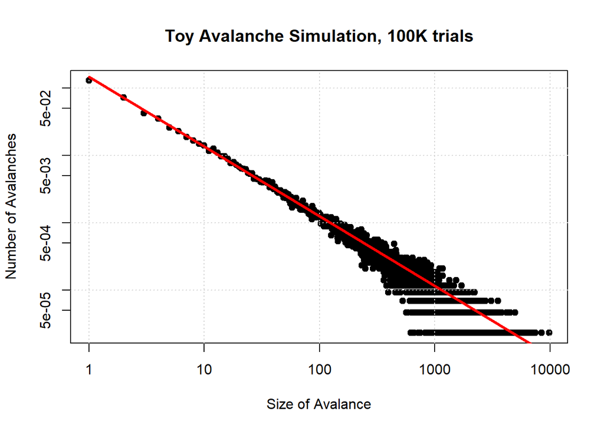

```r
# Look at the actual avalanches
zzz=diff(y); zzz=zzz[zzz>0]
d=as.data.frame(table(zzz),stringsAsFactors=F)
colnames(d)=c('x','y')
d$x=as.numeric(d$x)
d$y=d$y/sum(d$y)
plot(d$x,d$y,pch=19,log='xy',xlab='Size of Avalance',ylab='Number of Avalanches')
title('Toy Avalanche Simulation, 100K trials')
grid()
# For the linear approximation:
#
# Look at the first two decades of response -- larger avalanches are very rare
# so the fit doesn't quite follow a power law unless a very large number of trials
# are performed.
d2=d[d$x<=100,]
m=lm(log(y)~log(x),d2)
xnew=c(1,10000)
ynew=exp(predict(m,data.frame(x=xnew)))
lines(xnew,ynew,col='red',lwd=3)
```

Since we get a nominally straight line on a log-log plot it is clear that there is a power law in effect.

In addition to the log-log line plot – the largest 100 avalanches have been turned into images showing the before/after change due to adding a single element to the grid. Cells that are unchanged are white, small changes are yellow and large changes are red. These can be viewed as static images or played in a video loop – although they are not really sequential (these are before/after images of 100 different avalanches).

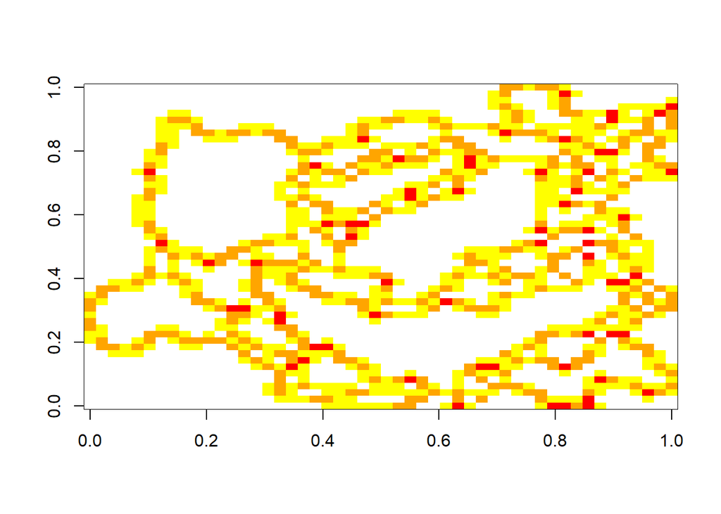

```r
image(savalanche,col=c('white','yellow','orange','red'))
```

The equation for the power law can be teased from the regression summary:

```r
summary(m)
```

```
##
## Call:
## lm(formula = log(y) ~ log(x), data = d2)
##
## Residuals:
##       Min        1Q    Median        3Q       Max
## -0.259777 -0.048975  0.000788  0.057959  0.199913
##
## Coefficients:
##              Estimate Std. Error t value Pr(>|t|)
## (Intercept) -1.921453   0.035588  -53.99   <2e-16 ***
## log(x)      -1.034406   0.009483 -109.08   <2e-16 ***
## ---
## Signif. codes:  0 '***' 0.001 '**' 0.01 '*' 0.05 '.' 0.1 ' ' 1
##
## Residual standard error: 0.08757 on 98 degrees of freedom
## Multiple R-squared:  0.9918, Adjusted R-squared:  0.9917
## F-statistic: 1.19e+04 on 1 and 98 DF,  p-value: < 2.2e-16
```

So: log(y) = -1.921453 - 1.034406*log(x)

or: y ~ 0.1463941/(x^1.0344)

Which is, essentially, 1/f.